# Clonality and the evolution of complex multi-cellularity

This script re-creates the analyses of Fisher et al 2013 using this dataset. As this dataset is built on the data from that study (with the addition of a small number of plants), then the results should be v. similar.

# 1 Pre-amble

## 1.1 load packages

```r
library(ape)
library(ggplot2)
library(tidyverse)
library(knitr)
library(brms) #https://rdrr.io/cran/brms/f/vignettes/brms_phylogenetics.Rmd
library(tidybayes)
library(rotl) #see https://cran.r-project.org/web/packages/rotl/vignettes/rotl.html
```

## 1.2 read in data

```r
df<- read.csv('data/germline_data_1.0.csv') #read in csv
```

## 1.3 create phylogeny files

```r
ResolvedNames <- tnrs_match_names(df$species.updated.rotl, context_name = 'All life') #search for similar names in the 'open tree of life' project (ROTL)
ResolvedNames$IsInTree <- is_in_tree(ResolvedNames$ott_id) #T/F, did the above find a match that can be put in the phylogeny?
```

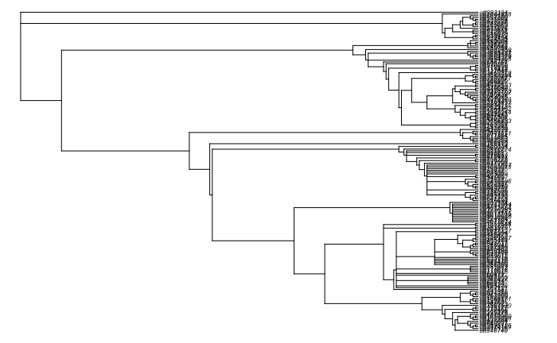

```r
#plot phylogeny to check
plot(AllTree, no.margin = TRUE, cex = 0.5, label.offset = 0.5)
```

# 2 Recreating results in Fisher without phylogeny

As practise for analyses of germline data.

## 2.1 is clonal group formation more likely to produce obligate multi-cellularity?

### 2.1.1 eyeball the data

Summary table to eyeball results:

```r
summary<- df %>%
  group_by(Obligate_or_facultative) %>%
  count()#summary table just to check that the results kinda fit

print(summary)
```

| Obligate_or_facultative | n |
| --- | --- |
| facultative | 30 |
| obligate | 166 |

### 2.1.2 defining the model

Have defined a v. simple, pretty non-informative prior (makes everything run faster). As a default, brms has flat prior, but defining a simple prior makes things run a bit quicker.

```r
get_prior(log(cell_number) ~ 0 + clonal, family=gaussian(), data = df) #what priors do we need to define?
```

```
Rows containing NAs were excluded from the model.
```

```
                 prior class             coef group resp dpar nlpar bound       source
                (flat)     b                                                   default
                (flat)     b     clonalclonal                             (vectorized)
                (flat)     b clonalnonMclonal                             (vectorized)
 student_t(3, 0, 11.1) sigma                                                   default
```

```r
#fit the model
fit_obl<-
  brm(data = df,
      family=bernoulli(link = 'logit'), # family of model
      formula = Obligate_or_facultative ~ 0 + clonal,  #formula, the 0 means that there are estimates for both clonal and non-clonal, rather than relative to each other
      iter = 600000, warmup = 10000, chains = 5,thin = 100, cores = 5, #chain settings
      prior = prior(normal(0, 10), "b"), #defining the priors- for things in 'class b' set this prior. (can also use get_priors() and set_priors() fucncitons)
      file = 'fits/obligate' )
```

### 2.1.3 Assessing model:

Assessing whether the chains converged, whether the predictions are okay, etc.

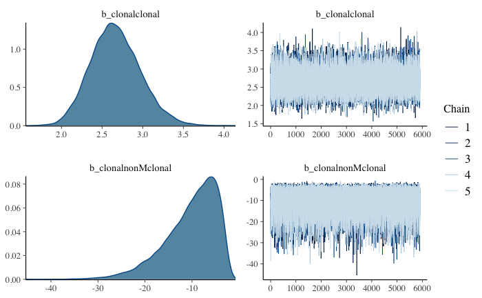

```r
plot(fit_obl) #check that chains converged
```

```
Using 10 posterior samples for ppc type 'dens_overlay' by default.
```

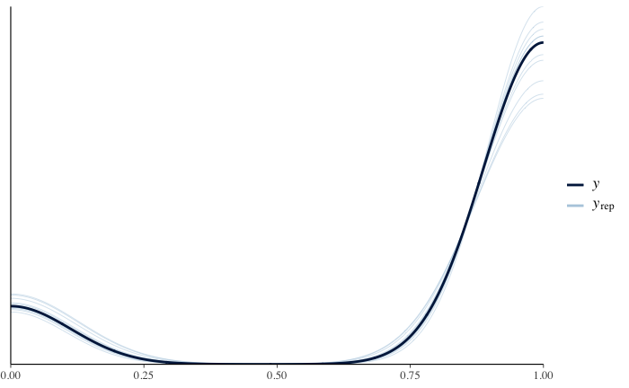

```r
pp_check(fit_obl) #check the predictions
```

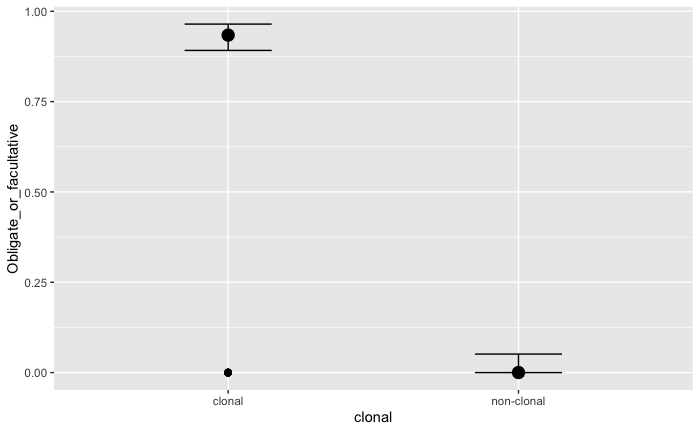

```r
plot(conditional_effects(fit_obl), points = TRUE) #show the effects of the c
```

```r
summary(fit_obl)
```

```
 Family: bernoulli
  Links: mu = logit
Formula: Obligate_or_facultative ~ 0 + clonal
   Data: df (Number of observations: 196)
Samples: 5 chains, each with iter = 6e+05; warmup = 10000; thin = 100;
         total post-warmup samples = 29500

Population-Level Effects:
                 Estimate Est.Error l-95% CI u-95% CI Rhat Bulk_ESS Tail_ESS
clonalclonal         2.67      0.30     2.11     3.30 1.00    29667    29421
clonalnonMclonal   -10.22      5.56   -23.74    -2.92 1.00    29290    28103

Samples were drawn using sampling(NUTS). For each parameter, Bulk_ESS
and Tail_ESS are effective sample size measures, and Rhat is the potential
scale reduction factor on split chains (at convergence, Rhat = 1).
```

```r
posterior_summary(fit_obl, robust = T) #what are the medians for coefficients? if F, then returns means
```

```
                    Estimate Est.Error      Q2.5      Q97.5
b_clonalclonal       2.65180 0.3025248   2.10845   3.304549
b_clonalnonMclonal  -9.05230 5.2035749 -23.73549  -2.918882
lp__               -51.40163 0.7477336 -54.46787 -50.679866
```

### 2.1.4 Hypothesis testing

```r
hyp = hypothesis(fit_obl,  "clonalclonal > clonalnonMclonal") #test hypothesis that clonal is more likely to produce obligate multicellularity
hyp
```

```
Hypothesis Tests for class b:
```

| Hypothesis | Estimate | Est.Error | CI.Lower | CI.Upper | Evid.Ratio | Post.Prob | Star |
| --- | --- | --- | --- | --- | --- | --- | --- |
| (clonalclonal)-(c... > 0 | 12.89 | 5.57 | 6.06 | 23.64 | Inf | 1 | * |

```
---
'CI': 90%-CI for one-sided and 95%-CI for two-sided hypotheses.
'*': For one-sided hypotheses, the posterior probability exceeds 95%;
for two-sided hypotheses, the value tested against lies outside the 95%-CI.
Posterior probabilities of point hypotheses assume equal prior probabilities.
```

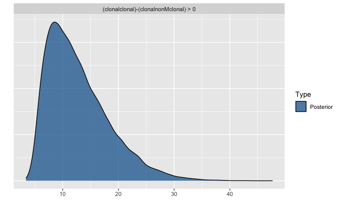

```r
plot(hyp)
```

## 2.2 does clonal group formation produce groups with more cells?

### 2.2.1 eyeball the data

```r
df %>%
  group_by(clonal) %>%
  summarise(cell_mean = mean(log(cell_number), na.rm = T)) #summary table just to check that the results kinda fit
```

| clonal | cell_mean |
| --- | --- |
| clonal | 13.921477 |
| non-clonal | 9.229133 |

```r
NA
```

### 2.2.2 define the model

```r
#fit the model
fit_num<-
  brm(data = df,
      family=gaussian(),
      formula = log(cell_number) ~ 0 + clonal,
      iter = 600000, warmup = 100000, chains = 5, thin = 100, cores = 5,
      prior = prior(normal(0, 10), "b"), file = 'fits/cell_number' ) # same simple prior
```

### 2.2.3 assess the model

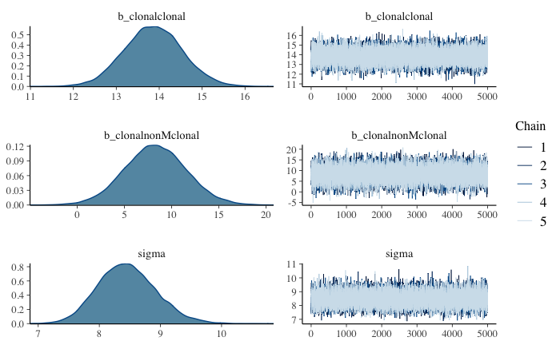

```r
plot(fit_num) #check that chains converged
```

```
Using 10 posterior samples for ppc type 'dens_overlay' by default.
```

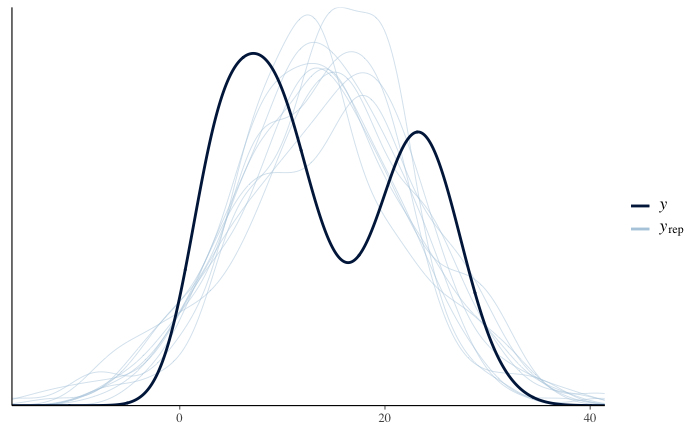

```r
pp_check(fit_num) #check the predictions
```

```r
summary(fit_num) #summary of model
```

```
 Family: gaussian
  Links: mu = identity; sigma = identity
Formula: log(cell_number) ~ 0 + clonal
   Data: df (Number of observations: 163)
Samples: 5 chains, each with iter = 6e+05; warmup = 1e+05; thin = 100;
         total post-warmup samples = 25000

Population-Level Effects:
                 Estimate Est.Error l-95% CI u-95% CI Rhat Bulk_ESS Tail_ESS
clonalclonal        13.86      0.68    12.55    15.21 1.00    25188    24284
clonalnonMclonal     8.27      3.28     1.85    14.79 1.00    24753    24544

Family Specific Parameters:
      Estimate Est.Error l-95% CI u-95% CI Rhat Bulk_ESS Tail_ESS
sigma     8.45      0.47     7.59     9.44 1.00    24777    25323

Samples were drawn using sampling(NUTS). For each parameter, Bulk_ESS
and Tail_ESS are effective sample size measures, and Rhat is the potential
scale reduction factor on split chains (at convergence, Rhat = 1).
```

```r
posterior_summary(fit_num, robust = T)
```

```
                      Estimate Est.Error        Q2.5       Q97.5
b_clonalclonal       13.863307 0.6728002   12.553205   15.205043
b_clonalnonMclonal    8.258856 3.2372365    1.850704   14.790212
sigma                 8.436409 0.4716049    7.585364    9.437379
lp__               -587.293513 1.0002830 -590.835724 -586.200693
```

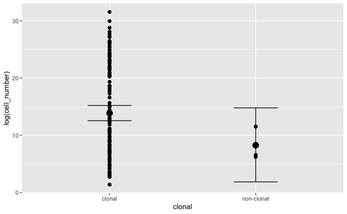

```r
plot(conditional_effects(fit_num), points = TRUE)
```

### 2.2.4 Hypothesis testing

```r
hyp = hypothesis(fit_num,  "clonalclonal > clonalnonMclonal") #test hypothesis that there is no difference based on coefficients
hyp
```

```
Hypothesis Tests for class b:
```

| Hypothesis | Estimate | Est.Error | CI.Lower | CI.Upper | Evid.Ratio | Post.Prob | Star |
| --- | --- | --- | --- | --- | --- | --- | --- |
| (clonalclonal)-(c... > 0 | 5.59 | 3.35 | 0.07 | 11.06 | 19.87 | 0.95 | * |

```
---
'CI': 90%-CI for one-sided and 95%-CI for two-sided hypotheses.
'*': For one-sided hypotheses, the posterior probability exceeds 95%;
for two-sided hypotheses, the value tested against lies outside the 95%-CI.
Posterior probabilities of point hypotheses assume equal prior probabilities.
```

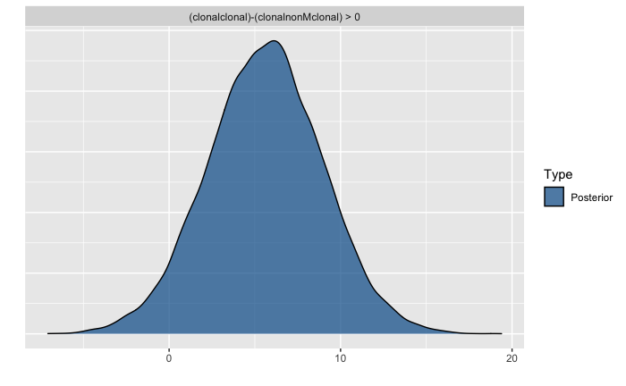

```r
plot(hyp)
```

## 2.3 Cell types

### 2.3.1 eyeball the data

```r
df %>%
  group_by(clonal) %>%
  summarise(cell_mean = mean(cell_types, na.rm = T)) #summary table just to check that the results kinda fit
```

| clonal | cell_mean |
| --- | --- |
| clonal | 12.058140 |
| non-clonal | 1.833333 |

### 2.3.2 define the model

This model has scaled, log transforemed cell number as an explanatory variable (as we expect more cells to lead to more cell types)

```r
fit_type<-
  brm(data = df,
      family=poisson(),
      formula = cell_types ~ 0 + clonal + scale(log(cell_number)),
      iter = 600000, warmup = 100000, chains = 5, thin = 1000, cores = 5,
      prior = prior(normal(0, 10), "b"), file = 'fits/cell_type')
```

### 2.3.3 assess the model

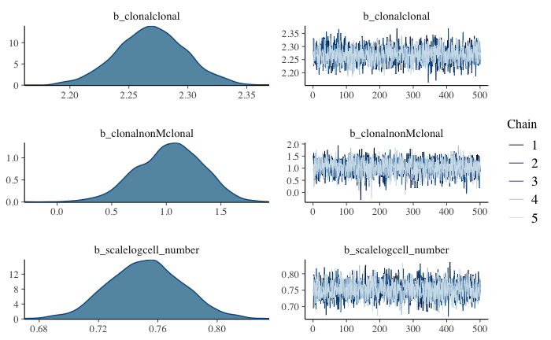

```r
plot(fit_type) #check that chains converged
```

```
Using 10 posterior samples for ppc type 'dens_overlay' by default.
```

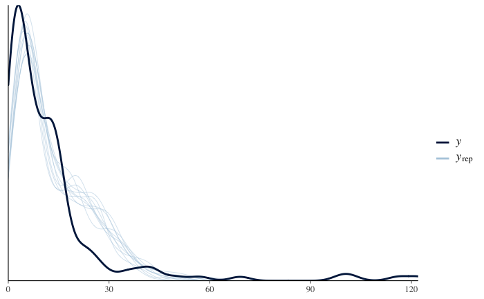

```r
pp_check(fit_type) #check the predictions
```

```r
summary(fit_type) #summary of model
```

```
 Family: poisson
  Links: mu = log
Formula: cell_types ~ 0 + clonal + scale(log(cell_number))
   Data: df (Number of observations: 162)
Samples: 5 chains, each with iter = 6e+05; warmup = 1e+05; thin = 1000;
         total post-warmup samples = 2500

Population-Level Effects:
                    Estimate Est.Error l-95% CI u-95% CI Rhat Bulk_ESS Tail_ESS
clonalclonal            2.27      0.03     2.21     2.33 1.00     2676     2486
clonalnonMclonal        1.03      0.30     0.41     1.58 1.00     2728     2443
scalelogcell_number     0.75      0.02     0.70     0.80 1.00     2546     2233

Samples were drawn using sampling(NUTS). For each parameter, Bulk_ESS
and Tail_ESS are effective sample size measures, and Rhat is the potential
scale reduction factor on split chains (at convergence, Rhat = 1).
```

```r
posterior_summary(fit_type, robust = T)
```

```
                           Estimate  Est.Error          Q2.5         Q97.5
b_clonalclonal            2.2690167 0.02897709     2.2113238     2.3269519
b_clonalnonMclonal        1.0455663 0.30428458     0.4141701     1.5754124
b_scalelogcell_number     0.7520086 0.02518929     0.7035575     0.8003034
lp__                  -1091.3447633 1.03820336 -1094.8437496 -1090.1964288
```

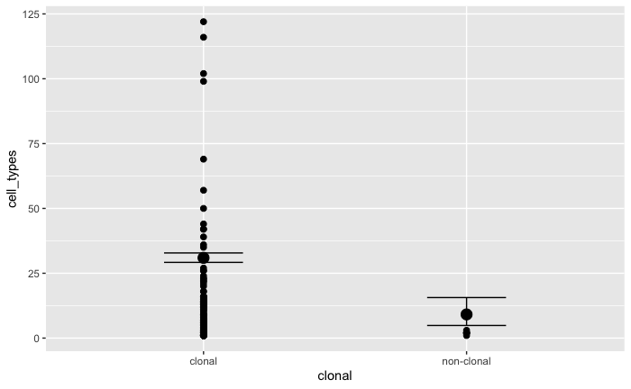

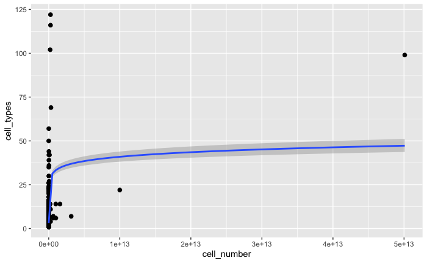

```r
plot(conditional_effects(fit_type), points = TRUE, ask = F)
```

### 2.3.4 hypothesis testing

```r
hyp = hypothesis(fit_type,  "clonalclonal > clonalnonMclonal") #test hypothesis that there is no difference based on coefficients
hyp
```

```
Hypothesis Tests for class b:
```

| Hypothesis | Estimate | Est.Error | CI.Lower | CI.Upper | Evid.Ratio | Post.Prob | Star |
| --- | --- | --- | --- | --- | --- | --- | --- |
| (clonalclonal)-(c... > 0 | 1.24 | 0.3 | 0.77 | 1.75 | Inf | 1 | * |

```
---
'CI': 90%-CI for one-sided and 95%-CI for two-sided hypotheses.
'*': For one-sided hypotheses, the posterior probability exceeds 95%;
for two-sided hypotheses, the value tested against lies outside the 95%-CI.
Posterior probabilities of point hypotheses assume equal prior probabilities.
```

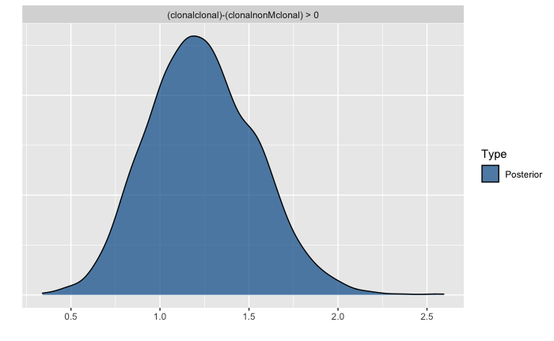

```r
plot(hyp)
```

```r
hyp = hypothesis(fit_type,  "scalelogcell_number = 0") #does cell number have an effect?
hyp
```

```
Hypothesis Tests for class b:
```

| Hypothesis | Estimate | Est.Error | CI.Lower | CI.Upper | Evid.Ratio | Post.Prob | Star |
| --- | --- | --- | --- | --- | --- | --- | --- |
| (scalelogcell_num... = 0 | 0.75 | 0.02 | 0.7 | 0.8 | NA | NA | * |

```
---
'CI': 90%-CI for one-sided and 95%-CI for two-sided hypotheses.
'*': For one-sided hypotheses, the posterior probability exceeds 95%;
for two-sided hypotheses, the value tested against lies outside the 95%-CI.
Posterior probabilities of point hypotheses assume equal prior probabilities.
```

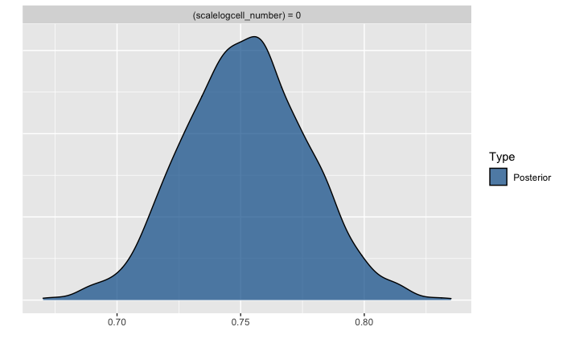

```r
plot(hyp)
```

## 2.4 Simple vs Complex multicellularity

### 2.4.1 eyeball the data

```r
summary<- df %>%
  group_by(Simple_or_complex) %>%
  count()#summary table just to check that the results kinda fit

print(summary)
```

| Simple_or_complex | n |
| --- | --- |
| complex | 113 |
| simple | 83 |

### 2.4.2 define model

```r
#fit the model
fit_complex<-
  brm(data = df,
      family=bernoulli(link = 'logit'),
      formula = Simple_or_complex ~ 0 + clonal,
      iter = 600000, warmup = 10000, chains = 5,thin = 100, cores = 5,
      prior = prior(normal(0, 10), "b"), file = 'fits/fit_complex' )
```

### 2.4.3 assess model

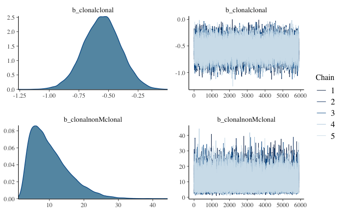

```r
plot(fit_complex) #check that chains converged
```

```
Using 10 posterior samples for ppc type 'dens_overlay' by default.
```

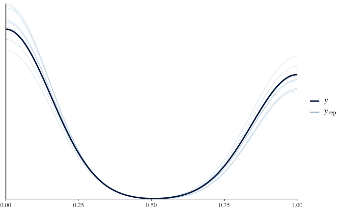

```r
pp_check(fit_complex) #check the predictions
```

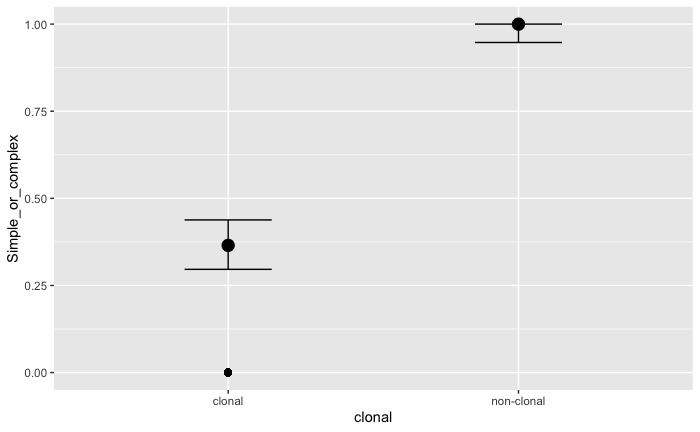

```r
plot(conditional_effects(fit_complex), points = TRUE)
```

```r
summary(fit_complex)
```

```
 Family: bernoulli
  Links: mu = logit
Formula: Simple_or_complex ~ 0 + clonal
   Data: df (Number of observations: 196)
Samples: 5 chains, each with iter = 6e+05; warmup = 10000; thin = 100;
         total post-warmup samples = 29500

Population-Level Effects:
                 Estimate Est.Error l-95% CI u-95% CI Rhat Bulk_ESS Tail_ESS
clonalclonal        -0.55      0.16    -0.87    -0.25 1.00    29250    28941
clonalnonMclonal    10.20      5.58     2.89    23.70 1.00    29484    29122

Samples were drawn using sampling(NUTS). For each parameter, Bulk_ESS
and Tail_ESS are effective sample size measures, and Rhat is the potential
scale reduction factor on split chains (at convergence, Rhat = 1).
```

```r
posterior_summary(fit_complex, robust = T) #what are the medians for coefficients? if F, then returns means
```

```
                       Estimate Est.Error         Q2.5        Q97.5
b_clonalclonal       -0.5533675 0.1562046   -0.8651276   -0.2490995
b_clonalnonMclonal    8.9919186 5.2215534    2.8878361   23.7011842
lp__               -124.2440286 0.7580379 -127.2818288 -123.5238834
```

### 2.4.4 Hypothesis testing

```r
hyp = hypothesis(fit_complex,  "clonalclonal > clonalnonMclonal") #test hypothesis that there is no difference based on coefficients
hyp
```

```
Hypothesis Tests for class b:
```

| Hypothesis | Estimate | Est.Error | CI.Lower | CI.Upper | Evid.Ratio | Post.Prob | Star |
| --- | --- | --- | --- | --- | --- | --- | --- |
| (clonalclonal)-(c... > 0 | -10.75 | 5.58 | -21.61 | -3.95 | 0 | 0 |  |

```
---
'CI': 90%-CI for one-sided and 95%-CI for two-sided hypotheses.
'*': For one-sided hypotheses, the posterior probability exceeds 95%;
for two-sided hypotheses, the value tested against lies outside the 95%-CI.
Posterior probabilities of point hypotheses assume equal prior probabilities.
```

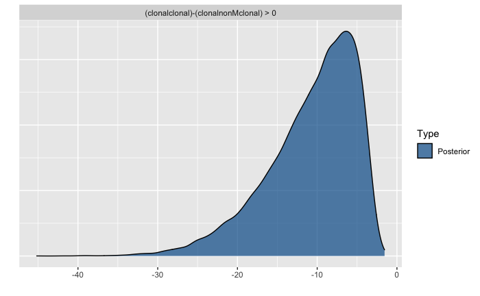

```r
plot(hyp)
```

# 3 Results with phylogeny included

```r
#read in phylogeny
phylo<- ape::read.tree('data/phylogeny_all.txt')
#subset df above with just those that are in the tree (note some missing)
names_in_tree<- read.csv('data/phylogeny_species_names_in_tree.csv')
names_in_tree$ott_id<- paste('ott',names_in_tree$ott_id, sep = '')
#phylo$tip.label %in% names_in_tree$ott_id #to check whether they're all present
names_in_tree<- subset(names_in_tree, names_in_tree$ott_id %in% phylo$tip.label)
#which species in the table are in the tree
df$species.updated.rotl<- tolower(df$species.updated.rotl)
df<- subset(df, tolower(df$species.updated.rotl) %in% tolower(names_in_tree$search_string))
#give them the ids in a column sot hat brms can match it up
df$species_id<- names_in_tree$ott_id
```

Covariance matrix produced using branch lengths of 1 (as in Fisher et al)

```r
# set branch lengths to 1 for covariance matrix
phylo_1b <- compute.brlen(phylo, 1)
#create covariance matrix
CovarMatrix <- ape::vcv.phylo(phylo_1b)
```

## 3.1 is clonal group formation more likely to produce obligate multi-cellularity?

### 3.1.1 define the model

```r
# what priors do we need to define?
get_prior(data = df,
      family=bernoulli(link = 'logit'),
      formula = Obligate_or_facultative ~ 0 + clonal + (1|gr(species_id, cov = CovarMatrix)),
      data2 = list(CovarMatrix = CovarMatrix))
```

```
                prior class             coef      group resp dpar nlpar bound       source
               (flat)     b                                                        default
               (flat)     b     clonalclonal                                  (vectorized)
               (flat)     b clonalnonMclonal                                  (vectorized)
 student_t(3, 0, 2.5)    sd                                                        default
 student_t(3, 0, 2.5)    sd                  species_id                       (vectorized)
 student_t(3, 0, 2.5)    sd        Intercept species_id                       (vectorized)
```

```r
fit_obl_phy<-
  brm(data = df,
      family=bernoulli(link = 'logit'),
      formula = Obligate_or_facultative ~ 0 + clonal + (1|gr(species_id, cov = CovarMatrix)),
      data2 = list(CovarMatrix = CovarMatrix),
      iter = 600000, warmup = 100000, chains = 5, thin = 150, cores = 5,
      prior = c(prior(student_t(3, 0, 20), "sd"),
                prior(normal(0, 10), "b")), file = 'fits/obl_phy')
```

[output not shown]

### 3.1.2 Assessing model:

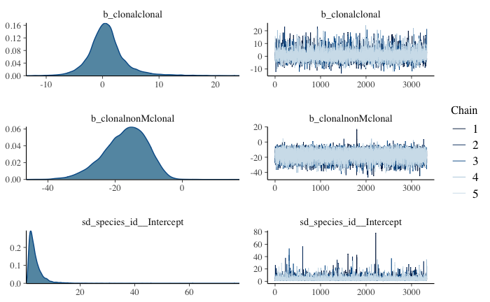

```r
plot(fit_obl_phy) #check that chains converged
```

```r
pp_check(fit_obl_phy) #check the predictions
```

[output not shown]

```
Using 10 posterior samples for ppc type 'dens_overlay' by default.
```

```r
plot(conditional_effects(fit_obl_phy), points = TRUE)
```

[output not shown]

## 3.2 does clonal group formation produce groups with more cells?

### 3.2.1 define the model

```r
#fit the model
fit_num_phy<-
  brm(data = df,
      family=gaussian(),
      formula = log(cell_number) ~ 0 + clonal + (1|gr(species_id, cov = CovarMatrix)),
      iter = 600000, warmup = 100000, chains = 5, thin = 100, cores = 5,
      prior = prior(normal(0, 10), "b"), file = 'fits/cell_number_phy', # same simple prior
      data2 = list(CovarMatrix = CovarMatrix))
```

```
Rows containing NAs were excluded from the model.Compiling Stan program...
```

[output not shown]